# Differential Expression of Oral sc carcinoma cells

## EDA

There are two main steps in this workflow, which are useful to separate conceptually: the one we will see first involves transformations of the counts in order to visually explore sample relationships. In the second step, we will go back to the original raw counts for statistical testing. This is critical because the statistical testing methods rely on original count data (not scaled or transformed) for calculating the precision of measurements.

```r
suppressMessages(library(DESeq2))
dds <- suppressMessages(DESeqDataSetFromMatrix(countData = count, colData = coldata, design = ~condition))
rldds <-rlog(dds)
dds <- estimateSizeFactors(dds)
```

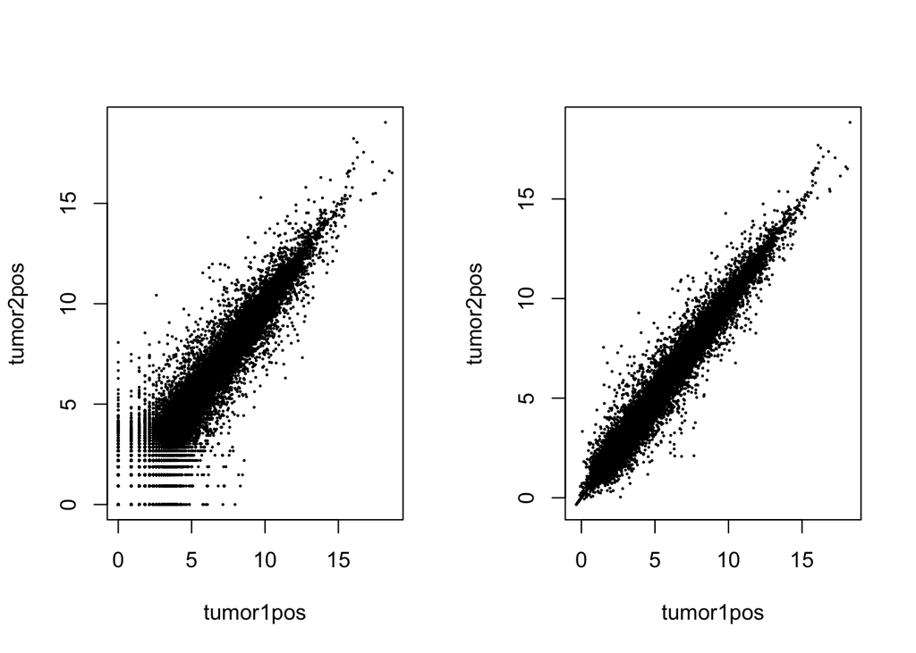

```r
par(mfrow=c(1,2))
plot(log2(counts(dds, normalized=TRUE)[,1:2] + 1),pch=16, cex=0.3)
plot(assay(rldds)[,1:2],pch=16, cex=0.3)
```

We can see how genes with low counts (bottom left-hand corner) seem to be excessively variable on the ordinary logarithmic scale, while the rlog transform compresses differences for the low count genes for which the data provide little information about differential expression.

```r
dds <- suppressMessages(DESeq(dds))
res <- results(dds)
res <- res[order(res$padj),]
vsdata <- vst(dds, blind=FALSE)
```

```r
library(gridExtra)
```

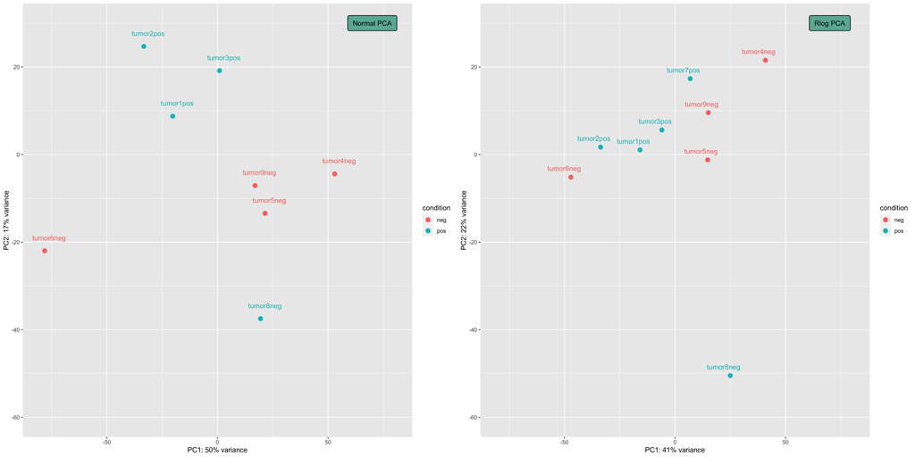

```r
rlpcadata <- plotPCA(rldds, intgroup = "condition", returnData=TRUE)
pcadata <- plotPCA(vsdata, intgroup="condition", returnData=TRUE)

percentVar <- round(100 * attr(pcadata, "percentVar"))
percentVarr <- round(100 * attr(rlpcadata, "percentVar"))



p1 <- ggplot(pcadata, aes(PC1, PC2, color = condition)) + geom_point(size=3) +
  geom_text(label=rownames(pcadata),nudge_x = 2,nudge_y = 3)+
   geom_label(
    label="Normal PCA",
    x=70,
    y=30,
    label.padding = unit(0.55, "lines"), # Rectangle size around label
    label.size = 0.35,
    color = "black",
    fill="#69b3a2"
  )+
  xlim(-80,80)+
  ylim(-60,30)+
  xlab(paste0("PC1: ",percentVar[1],"% variance")) +
   ylab(paste0("PC2: ",percentVar[2],"% variance"))

p2 <- ggplot(rlpcadata, aes(PC1, PC2, color = condition)) + geom_point(size=3) +
  geom_text(label=rownames(rlpcadata),nudge_x =-3,nudge_y = 2)+
  geom_label(
    label="Rlog PCA",
    x=70,
    y=30,
    label.padding = unit(0.55, "lines"), # Rectangle size around label
    label.size = 0.35,
    color = "black",
    fill="#69b3a2"
  )+
  xlim(-80,80)+
  ylim(-60,30)+
  xlab(paste0("PC1: ",percentVarr[1],"% variance")) +
   ylab(paste0("PC2: ",percentVarr[2],"% variance"))

grid.arrange(p1,p2, nrow=1)
```

```r
list <- c("ENSG00000188856.6","ENSG00000156076.10", "ENSG00000185069.2",
          "ENSG00000091128.13", "ENSG00000259781.1" ,  "ENSG00000134240.12")

#par(mfrow=c(2,3))
#for(i in list){
#  plotCounts(dds, gene= i, intgroup="condition")
#  }
```

```r
#library("EnhancedVolcano")

#EnhancedVolcano(res,
#    lab = rownames(res),
#    x = "log2FoldChange",
#    y = "pvalue",
#    pCutoff = 10e-4,
#    FCcutoff = 2,
#    ylim = c(0, -log10(10e-7)),
#    xlim = c(-5,5),
#    pointSize = c(ifelse(res$log2FoldChange>2, 8, 1)),
#    labSize = 6.0,
#    shape = c(6, 6, 19, 16),
#    title = "DESeq2 results",
#    subtitle = "Differential expression",
#    caption = bquote(~Log[2]~ "fold change cutoff, 2; p-value cutoff, 10e-4"),
#    legendPosition = "right",
#    legendLabSize = 14,
#    colAlpha = 0.9,
#    colGradient = c('red3', 'royalblue'),
#    drawConnectors = TRUE,
#    hline = c(10e-8),
#    widthConnectors = 0.5)
```

Many common statistical methods for exploratory analysis of multidimensional data, for example clustering and principal components analysis (PCA), work best for data that generally has the same range of variance at different ranges of the mean values. When the expected amount of variance is approximately the same across different mean values, the data is said to be homoskedastic. For RNA-seq raw counts, however, the variance grows with the mean. For example, if one performs PCA directly on a matrix of size-factor-normalized read counts, the result typically depends only on the few most strongly expressed genes because they show the largest absolute differences between samples. A simple and often used strategy to avoid this is to take the logarithm of the normalized count values plus a small pseudocount; however, now the genes with the very lowest counts will tend to dominate the results because, due to the strong Poisson noise inherent to small count values, and the fact that the logarithm amplifies differences for the smallest values, these low count genes will show the strongest relative differences between samples.

As a solution, DESeq2 offers transformations for count data that stabilize the variance across the mean. One such transformation is the regularized-logarithm transformation or rlog2. For genes with high counts, the rlog transformation will give similar result to the ordinary log2 transformation of normalized counts. For genes with lower counts, however, the values are shrunken towards the genes’ averages across all samples. Using an empirical Bayesian prior on inter-sample differences in the form of a ridge penalty, the rlog-transformed data then becomes approximately homoskedastic, and can be used directly for computing distances between samples and making PCA plots. Another transformation that similarly improves distance calculation across samples, the variance stabilizing transformation24 implemented in the vst function, is discussed alongside the rlog in the DESeq2 vignette.

The options for type are:

`apeglm` is the adaptive t prior shrinkage estimator from the apeglm package (Zhu, Ibrahim, and Love 2018). As of version 1.28.0, it is the default estimator.

`ashr` is the adaptive shrinkage estimator from the ashr package (Stephens 2016). Here DESeq2 uses the ashr option to fit a mixture of Normal distributions to form the prior, with method=“shrinkage”.

`normal` is the the original DESeq2 shrinkage estimator, an adaptive Normal distribution as prior.

```r
#plotMA(res, ylim=c(-5,5))
```

```r
#resLFC <- lfcShrink(dds, coef="condition_pos_vs_neg", type="apeglm")
#resNorm <- lfcShrink(dds, coef=2, type="normal")
#resAsh <- lfcShrink(dds, coef=2, type="ashr")

#par(mfrow=c(1,3), mar=c(4,4,2,1))

#plotMA(resLFC,ylim= c(.005,.005), main="apeglm")
#plotMA(resNorm,ylim= c(-3,3), main="normal")
#plotMA(resAsh,ylim= c(-5,5),main="ashr")
#reset par
```

What are s-values? This quantity proposed by Stephens (2016) gives the estimated rate of false sign among genes with equal or smaller s-value. Stephens (2016) points out they are analogous to the q-value of Storey (2003). The s-value has a desirable property relative to the adjusted p-value or q-value, in that it does not require supposing there to be a set of null genes with LFC = 0 (the most commonly used null hypothesis). Therefore, it can be benchmarked by comparing estimated LFC and s-value to the “true LFC” in a setting where this can be reasonably defined. For these estimated probabilities to be accurate, the scale of the prior needs to match the scale of the distribution of effect sizes, and so the original DESeq2 shrinkage method is not really compatible with computing s-values.

Total number of counted reads per sample is not a good estimate of library size. It is un-necessarily influenced by regions with large counts, and can introduce bias and correlation across genes. Instead, use a robust measure of library size that takes account of skew in the distribution of counts (simplest: trimmed geometric mean; more advanced / appropriate encountered in the lab). Library size (total number of counted reads) differs between samples, and should be included as a statistical offset in analysis of differential expression, rather than ‘dividing by’ the library size early in an analysis.

In this count matrix, each row represents an Ensembl gene, each column a sequenced RNA library, and the values give the raw numbers of fragments that were uniquely assigned to the respective gene in each library. We also have information on each of the samples (the columns of the count matrix). If you’ve counted reads with some other software, it is very important to check that the columns of the count matrix correspond to the rows of the sample information table.

## Citation

- M. I. Love, W. Huber, S. Anders: Moderated estimation of fold change and dispersion for RNA-Seq data with DESeq2. bioRxiv (2014). doi:10.1101/002832 [1]
- Zhu, A., Ibrahim, J.G., Love, M.I. (2018) Heavy-tailed prior distributions for sequence count data: removing the noise and preserving large differences. Bioinformatics. 10.1093/bioinformatics/bty895
- Stephens, M. (2016) False discovery rates: a new deal. Biostatistics, 18:2. 10.1093/biostatistics/kxw041
- Lauren Ashlock, Computational Biology Spring 2017, DESeq2 tutorial: https://lashlock.github.io/compbio/R_presentation.html

-https://www.bioconductor.org/packages/release/bioc/vignettes/EnhancedVolcano/inst/doc/EnhancedVolcano.html